# R Tutorial

#### Helpful Links

- **Link to Powerpoint** [here](https://docs.google.com/presentation/d/18Fjdpklo2-CYWFXUwlNXUsoQsEcITS0cbu4OPnBvbA0/edit?usp=sharing)

# Basic Set Up

## Set the Working Directory

- SUPER IMPORTANT STEP: You need this to locate files you’ll be importing
- `getwd()`: prints the working directory
- `setwd()`: setting the working directory manually
- Your working directory should contain all your data files!!!

```r
getwd()
```

```
## [1] "/Users/deepikadilip/Desktop/R_Tutorial"
```

```r
setwd('~/Desktop/R_Tutorial')
```

## Load Libraries

```r
library(tidyverse)
library(ggplot2)
```

## Importing the Data

- For our purposes, we are importing a TXT file
- REDCap offers imports using the CSV format (use the `read.csv` command)
- R supports both, along with multiple other formats (packages can help load Excel files)
- `names`: column names
- `nrow`: number of rows
- `ncol`: number of columns

```r
data_nhanes = read.delim("NHANES.txt", na.strings = NA)
head(data_nhanes)
```

```
##      ID SurveyYr Gender Age AgeDecade AgeMonths Race1 Race3    Education
## 1 51624  2009_10   male  34     30-39       409 White  <NA>  High School
## 2 51624  2009_10   male  34     30-39       409 White  <NA>  High School
## 3 51624  2009_10   male  34     30-39       409 White  <NA>  High School
## 4 51625  2009_10   male   4       0-9        49 Other  <NA>         <NA>
## 5 51630  2009_10 female  49     40-49       596 White  <NA> Some College
## 6 51638  2009_10   male   9       0-9       115 White  <NA>         <NA>
##   MaritalStatus    HHIncome HHIncomeMid Poverty HomeRooms HomeOwn       Work
## 1       Married 25000-34999       30000    1.36         6     Own NotWorking
## 2       Married 25000-34999       30000    1.36         6     Own NotWorking
## 3       Married 25000-34999       30000    1.36         6     Own NotWorking
## 4          <NA> 20000-24999       22500    1.07         9     Own       <NA>
## 5   LivePartner 35000-44999       40000    1.91         5    Rent NotWorking
## 6          <NA> 75000-99999       87500    1.84         6    Rent       <NA>
##   Weight Length HeadCirc Height   BMI BMICatUnder20yrs   BMI_WHO Pulse BPSysAve
```

[output cut: 62 more lines]

```r
names(data_nhanes)
```

```
##  [1] "ID"               "SurveyYr"         "Gender"           "Age"
##  [5] "AgeDecade"        "AgeMonths"        "Race1"            "Race3"
##  [9] "Education"        "MaritalStatus"    "HHIncome"         "HHIncomeMid"
## [13] "Poverty"          "HomeRooms"        "HomeOwn"          "Work"
## [17] "Weight"           "Length"           "HeadCirc"         "Height"
## [21] "BMI"              "BMICatUnder20yrs" "BMI_WHO"          "Pulse"
## [25] "BPSysAve"         "BPDiaAve"         "BPSys1"           "BPDia1"
## [29] "BPSys2"           "BPDia2"           "BPSys3"           "BPDia3"
## [33] "Testosterone"     "DirectChol"       "TotChol"          "UrineVol1"
## [37] "UrineFlow1"       "UrineVol2"        "UrineFlow2"       "Diabetes"
## [41] "DiabetesAge"      "HealthGen"        "DaysPhysHlthBad"  "DaysMentHlthBad"
## [45] "LittleInterest"   "Depressed"        "nPregnancies"     "nBabies"
## [49] "Age1stBaby"       "SleepHrsNight"    "SleepTrouble"     "PhysActive"
## [53] "PhysActiveDays"   "TVHrsDay"         "CompHrsDay"       "TVHrsDayChild"
## [57] "CompHrsDayChild"  "Alcohol12PlusYr"  "AlcoholDay"       "AlcoholYear"
## [61] "SmokeNow"         "Smoke100"         "Smoke100n"        "SmokeAge"
## [65] "Marijuana"        "AgeFirstMarij"    "RegularMarij"     "AgeRegMarij"
## [69] "HardDrugs"        "SexEver"          "SexAge"           "SexNumPartnLife"
## [73] "SexNumPartYear"   "SameSex"          "SexOrientation"   "PregnantNow"
```

```r
nrow(data_nhanes)
```

```
## [1] 10000
```

If we want to see all the variables in the dataset, we can use the `str` command:

```r
str(data_nhanes)
```

```
## 'data.frame':    10000 obs. of  76 variables:
##  $ ID              : int  51624 51624 51624 51625 51630 51638 51646 51647 51647 51647 ...
##  $ SurveyYr        : chr  "2009_10" "2009_10" "2009_10" "2009_10" ...
##  $ Gender          : chr  "male" "male" "male" "male" ...
##  $ Age             : int  34 34 34 4 49 9 8 45 45 45 ...
##  $ AgeDecade       : chr  " 30-39" " 30-39" " 30-39" " 0-9" ...
##  $ AgeMonths       : int  409 409 409 49 596 115 101 541 541 541 ...
##  $ Race1           : chr  "White" "White" "White" "Other" ...
##  $ Race3           : chr  NA NA NA NA ...
##  $ Education       : chr  "High School" "High School" "High School" NA ...
##  $ MaritalStatus   : chr  "Married" "Married" "Married" NA ...
##  $ HHIncome        : chr  "25000-34999" "25000-34999" "25000-34999" "20000-24999" ...
##  $ HHIncomeMid     : int  30000 30000 30000 22500 40000 87500 60000 87500 87500 87500 ...
##  $ Poverty         : num  1.36 1.36 1.36 1.07 1.91 1.84 2.33 5 5 5 ...
##  $ HomeRooms       : int  6 6 6 9 5 6 7 6 6 6 ...
```

[output cut: 62 more lines]

# Data Manipulation

## Filtering Data

Here, we're selecting the weights of current smokers and storing it in an object called `tobacco_users_weights`. We're also selecting the weights of non-smokers and storing it in `non_tobacco_users_weights`.

- `%>%` is a way to send the data down to the next command. Instead of saying `data_nhanes <- filter(data_nhanes, Marijuana=="Yes")` followed by `data_nhanes <- select(data_nhanes, “Yes”)`
- `filter`: selects rows based on certain criteria. Here we’re selecting who indicated “Yes” under the SmokeNow variable
- `select`: this selects specific columns. Here, we’re selecting the Weight column

Without Piping:

```r
tobacco_users_weights <- filter(data_nhanes, SmokeNow=="Yes")
tobacco_users_weights <- select(tobacco_users_weights, Weight)
tobacco_users_weights <- unlist(tobacco_users_weights)


non_tobacco_users_weights <- filter(data_nhanes, SmokeNow=="No")
non_tobacco_users_weights <- select(non_tobacco_users_weights, Weight)
non_tobacco_users_weights <- unlist(non_tobacco_users_weights)
```

With Piping:

```r
tobacco_users_weights <- data_nhanes %>% filter(SmokeNow=="Yes") %>% select(Weight) %>% unlist
non_tobacco_users_weights <- data_nhanes %>% filter(SmokeNow=="No") %>% select(Weight) %>% unlist
```

## Creating a New Variable

What if we want to calculate everyone's age in years, using the `AgeMonths` variable and create a new variable called `AgeYears`? We can do this using the `mutate` function.

```r
data_nhanes <- data_nhanes %>% mutate(AgeYears = AgeMonths/12)
summary(data_nhanes$AgeYears)
```

```
##    Min. 1st Qu.  Median    Mean 3rd Qu.    Max.    NA's
##    0.00   16.58   34.83   35.01   52.00   79.92    5038
```

# Exploratory Data Analysis

### Histograms:

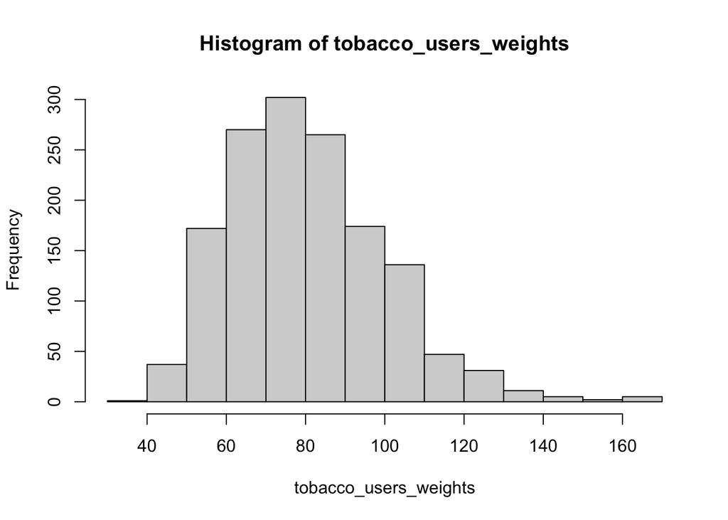

```r
hist(tobacco_users_weights)
```

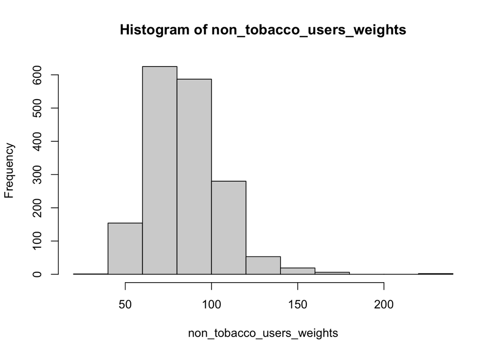

```r
hist(non_tobacco_users_weights)
```

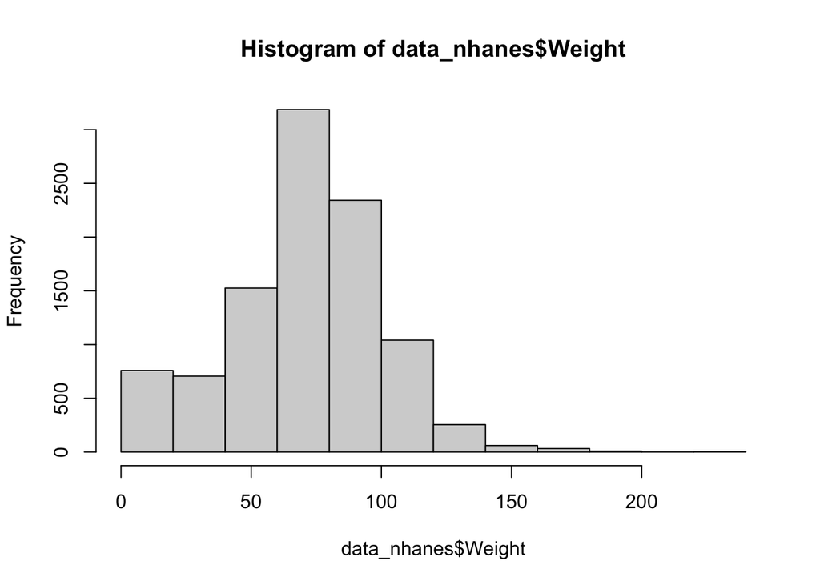

```r
hist(data_nhanes$Weight)
```

#### Want a prettier histogram? Use `ggplot2`:

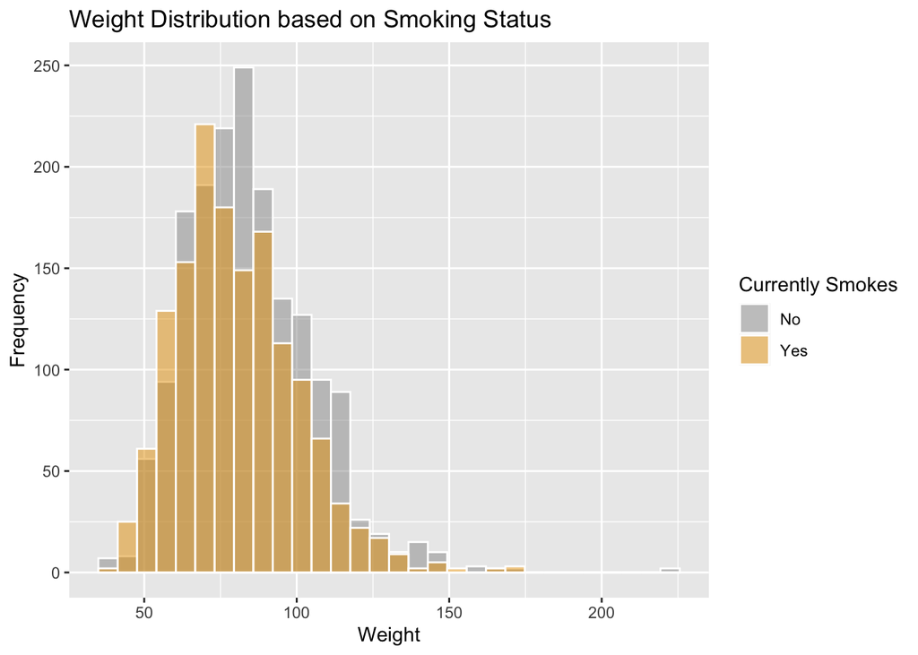

```r
ggplot(aes(x = Weight, fill = factor(SmokeNow)), data = filter(data_nhanes, !is.na(SmokeNow))) + geom_histogram(color = "white", alpha=0.5, position="identity") + labs(title = "Weight Distribution based on Smoking Status", x = "Weight", y = "Frequency", fill = "Currently Smokes") + scale_fill_manual(values=c("#999999", "#E69F00", "#56B4E9"))
```

### Basic Plots:

You can use the `$` sign to specify a column of the data frame

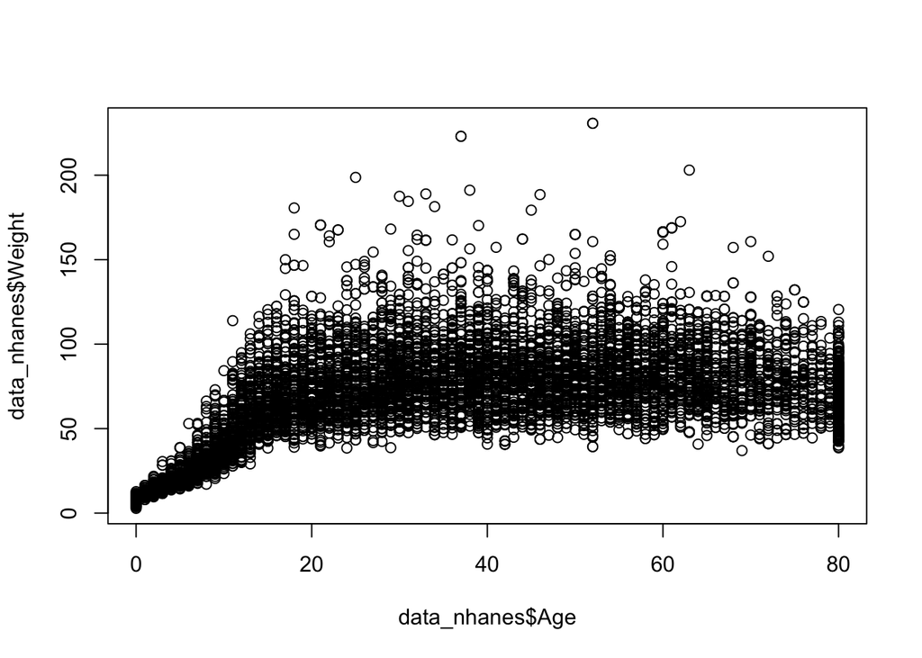

```r
# Plot of Weight vs Age
plot(data_nhanes$Age, data_nhanes$Weight)
```

# Statistical Tests:

### Summary Statistics

Note the difference between the two commands:

```r
mean(tobacco_users_weights)
```

```
## [1] NA
```

```r
mean(tobacco_users_weights, na.rm = T)
```

```
## [1] 80.53505
```

```r
median(tobacco_users_weights, na.rm = T)
```

```
## [1] 78.15
```

```r
sd(tobacco_users_weights, na.rm = T)
```

```
## [1] 19.72187
```

```r
summary(tobacco_users_weights)
```

```
##    Min. 1st Qu.  Median    Mean 3rd Qu.    Max.    NA's
##   38.70   66.40   78.15   80.54   92.30  168.80       8
```

### Continuous Outcomes: t-Test

We can use a t-test to compare two **continuous** outcomes between two groups.

Let's first visualize these using a boxplot:

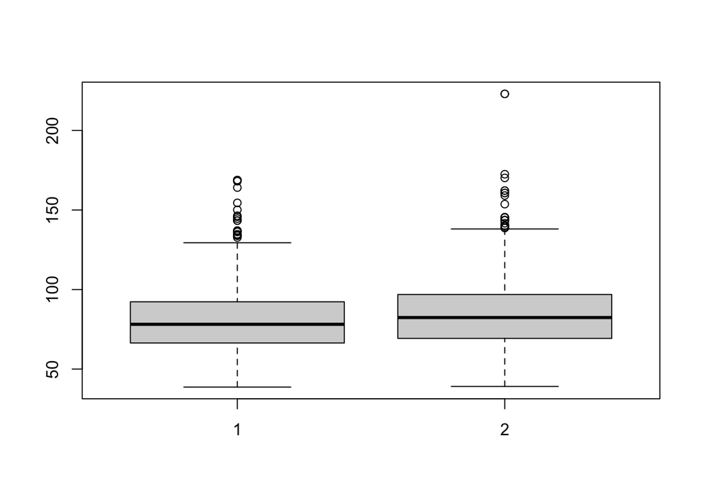

```r
boxplot(tobacco_users_weights, non_tobacco_users_weights)
```

Then we'll use a statistical test:

```r
t.test(tobacco_users_weights, non_tobacco_users_weights)
```

```
##
##  Welch Two Sample t-test
##
## data:  tobacco_users_weights and non_tobacco_users_weights
## t = -5.5235, df = 3138.1, p-value = 3.595e-08
## alternative hypothesis: true difference in means is not equal to 0
## 95 percent confidence interval:
##  -5.374468 -2.558447
## sample estimates:
## mean of x mean of y
##  80.53505  84.50151
```

### Catgorical Data Analysis:

Let's assume we want to compare the relationship between two CATEGORICAL variables, in this example, `Gender` and `HHIncome` (Income Bracket). We can visualize tables using the table command or via tidyverse:

```r
table(data_nhanes$Gender)
```

```
##
## female   male
##   5020   4980
```

```r
table(data_nhanes$HHIncome)
```

```
##
##      0-4999   5000-9999 10000-14999 15000-19999 20000-24999 25000-34999
##         192         254         543         527         617         958
## 35000-44999 45000-54999 55000-64999 65000-74999 75000-99999  more 99999
##         863         784         621         526        1084        2220
```

```r
table(data_nhanes$HHIncome, data_nhanes$Gender)
```

```
##
##               female male
##    0-4999        112   80
##    5000-9999     143  111
##   10000-14999    295  248
##   15000-19999    276  251
##   20000-24999    311  306
##   25000-34999    480  478
##   35000-44999    448  415
##   45000-54999    383  401
##   55000-64999    303  318
##   65000-74999    250  276
##   75000-99999    514  570
##   more 99999    1059 1161
```

```r
table(data_nhanes$HHIncome, data_nhanes$Gender, useNA = "always")
```

```
##
##               female male <NA>
##    0-4999        112   80    0
##    5000-9999     143  111    0
##   10000-14999    295  248    0
##   15000-19999    276  251    0
##   20000-24999    311  306    0
##   25000-34999    480  478    0
##   35000-44999    448  415    0
##   45000-54999    383  401    0
##   55000-64999    303  318    0
##   65000-74999    250  276    0
##   75000-99999    514  570    0
##   more 99999    1059 1161    0
##   <NA>           446  365    0
```

We can analyze the relationship between these two factors using a chi-squared test:

```r
chisq.test(table(data_nhanes$HHIncome, data_nhanes$Gender))
```

```
##
##  Pearson's Chi-squared test
##
## data:  table(data_nhanes$HHIncome, data_nhanes$Gender)
## X-squared = 25.383, df = 11, p-value = 0.008008
```

### Linear Models:

What if we want to see the effect multiple variables have on an outcome? We can use a linear model:

In this example, we'll look at the effects of age and weight on income:

```r
model = lm(HHIncomeMid ~ Age + Weight, data = data_nhanes)
summary(model)
```

```
##
## Call:
## lm(formula = HHIncomeMid ~ Age + Weight, data = data_nhanes)
##
## Residuals:
##    Min     1Q Median     3Q    Max
## -58578 -28163  -6294  32337  45304
##
## Coefficients:
##             Estimate Std. Error t value Pr(>|t|)
## (Intercept) 54545.67     918.10  59.412   <2e-16 ***
## Age            12.48      18.08   0.690   0.4899
## Weight         31.31      13.74   2.278   0.0227 *
## ---
## Signif. codes:  0 '***' 0.001 '**' 0.01 '*' 0.05 '.' 0.1 ' ' 1
##
## Residual standard error: 32990 on 9117 degrees of freedom
##   (880 observations deleted due to missingness)
## Multiple R-squared:  0.001093,   Adjusted R-squared:  0.0008738
## F-statistic: 4.988 on 2 and 9117 DF,  p-value: 0.006841
```